# Generalized Linear Mixed Model Analysis of CHOP Study Data

- Show All Code
- Hide All Code
- View Source

CSTAT Case: C1358  
Client: Masyr, Alison

Author

Affiliation

Steven J. Pierce

Michigan State University, Center for Statistical Training and Consulting

Published

2026-01-29 13:49:42 EST

Modified

2026-01-29 12:10:13 EST

# 1 Purpose

This file is part of a research compendium (Pierce, 2026). It runs a generalized linear mixed model (GLMM) on data about dogs receiving CHOP chemotherapy at MSU Veterinary Medicine Clinic (VMC) between 2016 and 2022. The study aims to assess the prevalence of bandemia (i.e., band neutrophil elevation) in canine lymphoma patients undergoing CHOP chemotherapy and test predictors of bandemia prevalence. Specifically, we examine the effects of two predictors: the drug administered and the dog’s body surface area (BSA). Some results here are used in a manuscript (Eliason et al., 2026).

# 2 Setup

This section of the report documents some setup tasks that are useful to the statistician on the team. Most readers of this report will probably want skip directly to Section 3.

## 2.1 Define Global Options

Global R chunk options are defined in the YAML header but local chunk options will over-ride global options. We can temporarily disable an individual chunk by inserting `#| eval: false` on a line at the top of the chunk.

## 2.2 Load Packages

Load R packages that we need to get additional functions.

````markdown
```{r}
#| label: load-packages
library(devtools)    # for session_info()
```
```{r}
#| label: load-packages
library(here)        # for here(), i_am()
```
````

```
here() starts at P:/Consulting/Cases_1200-1399/C1358/CHOPStudy/scripts
```

````markdown
```{r}
#| label: load-packages
library(tidyverse)   # loads dplyr, forcats, ggplot2, lubridate, purrr, readr,
```
```{r}
#| label: load-packages
                     # stringr, tibble, & tidyr by default.
                     # for filter(), group_by(), mutate(), rename(), summarise()
library(broom)       # for glance(), tidy()
library(broom.mixed) # for support for mixed models.
library(DHARMa)      # for plotQQunif(), plotResiduals(), simulateResiduals(),
```
```{r}
#| label: load-packages
                     # testDispersion()
library(glmmTMB)     # for diagnose(), glmmTMB()
library(marginaleffects)  # for predictions(), comparisons(), slopes(), etc.
```
```{r}
#| label: load-packages
library(modelsummary) # for modelsummary()
library(performance) # for check_model(), icc(), model_performance(), r2(),
                     # test_lrt()
library(knitr)       # for kable()
library(kableExtra)  # for kable_styling
```
```{r}
#| label: load-packages
library(piercer)     # for for brier(), display_num(), file_details(),
                     # git_report(), R2Dev()
library(quarto)      # for quarto_version()
library(CHOPStudy)   # for version info
```
````

## 2.3 Declare Path

````markdown
```{r}
#| label: declare-path

here::i_am(path = "scripts/Descriptive_Analysis.qmd")
```
````

```
here() starts at P:/Consulting/Cases_1200-1399/C1358/CHOPStudy
```

## 2.4 Load Data

**Caution**

Render the `scripts/Import_Data.qmd` file to create the data file loaded below.

Table 1 shows meta-data about the data file we will load.

````markdown
```{r}
#| label: tbl-imported-data-file
#| tbl-cap: "Meta-Data About the Imported Data File Loaded"

DataFile <- here("data/Imported_CHOP_Data.RData")

file_details(DataFile) %>%
  kable(, format = "html",
        col.names = c("File Name", "Size", "Last Modified")) %>%
  kable_styling()
```
````

Table 1: Meta-Data About the Imported Data File Loaded

| File Name | Size | Last Modified |
| --- | --- | --- |
| Imported_CHOP_Data.RData | 63.8K | 2026-01-29 13:45:43 |

````markdown
```{r}
#| label: load-data

load(file=here("data/Imported_CHOP_Data.RData"))
```
````

# 3 Methods

Each dog in the sample was undergoing CHOP chemotherapy, which involves administering different drugs according to a multi-phase protocol that stretches over multiple clinic visits. This analysis uses data from visits 1-10 during phase 1 of the protocol. The protocol specifies which drug should be administered at each visit, but there are deviations from the protocol based on clinical circumstances and professional judgement. At each visit, a CBC sample was collected and analyzed to measure the outcome.

We have a multilevel data structure with 530 visits and the associated CBC samples (level 1 [L1] units) nested within 90 dogs (level 2 [L2] units). The number of visits per dog varying from 1 to 10 (mean = 5.9, SD = 3.1).

Due to the high correlation between weight and body surface area (BSA), we have included only BSA in the model.

## 3.1 Measures

There are no missing data in the measures used in this analysis (see descriptive analysis output file). We centered the predictors to facilitate obtaining unconflated estimates of the effects of variables at each level of analysis (Rights et al., 2020; Rights & Sterba, 2023; Schielzeth, 2010; Yaremych et al., 2023).

### 3.1.1 Bandemia (`Bandemia`)

Our outcome for the logistic models is a binary variable measuring whether the CBC sample taken at a given visit exhibited bandemia, which was defined as having total band neutrophils $\gt$ 0.10 k/ul and coded (0 = No, 1 = Yes). This means that we can interpret estimated marginal means on the response scale as the prevalence rate of bandemia.

### 3.1.2 Age (`Age_Yrs`)

Age at the start of CHOP (`Age_Yrs`) was measured in years. This is a patient-level (L2) measure that was invariant across visits. Prior to modeling, we grand-mean centered this variable to improve interpretation of model coefficients (Schielzeth, 2010), yielding `Age_Yrs_C`.

### 3.1.3 Sex (‘Sex’)

Sex is a binary, dummy-coded, patient-level (L2) measure (0 = female, 1 = male).

### 3.1.4 Body Surface Area (`BSA_m2_C`)

Body surface area at the start of CHOP (`Surface_Area_m2`) was measured in square meters ($m^2$) at the beginning of the CHOP cycle. This is a patient-level (L2) measure that was invariant across visits. Prior to modeling, we grand-mean centered this variable to improve interpretation of model coefficients (Schielzeth, 2010), yielding `BSA_m2_C`.

### 3.1.5 Prior Drug Administered (`DrugC_C`, `DrugD_C`, `M_DrugC_C`, `M_DrugD_C`)

The drug administered prior to CBC sample collection (`Drug`) was treated as a nominal, categorical variable with three levels: 1, vincristine (the reference levels); 2, cyclophosphamide; and 3, doxorubicin. This was a visit-level (L1) variable. It was dummy coded into two variables: `DrugC` codes for whether the drug was cyclophosphamide (0 = no, 1 = yes) and `DrugD` codes for whether the drug was doxorubicin (0 = no, 1 = yes).

The dummy codes were aggregated to create L2 (patient-specific) means (`M_DrugC` and `M_DrugD`). These means were added to the GLMM as L2 predictors so we can properly control for drug when testing the effect of BSA at L2 (Rights et al., 2020; Rights & Sterba, 2023; Yaremych et al., 2023).

While the practice is unfamiliar to many researchers, centering L1 dummy-coded categorical predictors around their group means is necessary for obtaining unconflated estimates of their effects in multilevel models (Yaremych et al., 2023). Accordingly, we computed L1 group-mean centered versions of the L1 predictors, yielding `DrugC_C = DrugC - M_DrugC` and `DrugD_C = DrugD - M_DrugD`. The centered variables were used in the models.

## 3.2 Statistical Analysis

Generalized linear mixed models (GLMMs) with a logit link function were employed to assess the effects of each drug and BSA on presence of bandemia. This model was chosen to capture the random effects pertaining to repeated observations from each dog while dealing with the binary outcome. We set the Type I error rate at $\alpha = 0.05$. We used the glmmTMB package for R to fit the models (Brooks et al., 2017; McGillycuddy et al., 2025).

**Important**

Our manuscript (Eliason et al., 2026) will only report Model 2, but Models 0 and 1 are useful as part of a model building process. They help us better understand the data.

### 3.2.1 Model Fit Indices

We used the performance package (Lüdecke et al., 2021) to obtain a variety of common model fit indices for GLMMs, including AIC, BIC, ICC, and RMSE. In addition, it also reports the conditional and marginal $R^2$ (Nakagawa et al., 2017).

### 3.2.2 Effect Size Estimates

Interpretation was facilitated by using the `marginaleffects` package (Arel-Bundock et al., 2024) to obtain estimated marginal means for bandemia prevalence associated with each drug along with relevant 95% confidence intervals, risk differences (RD) for bandemia when comparing pairs of drugs, and graphing average predicted bandemia prevalence as a function of each continuous predictor. We also estimated the odds ratio (OR) for each predictor along with 95% confidence intervals.

### 3.2.3 Collinearity

The `performance` package (Lüdecke et al., 2021) provides a function for examining the generalized variance inflation factor (GVIF) (Fox & Weisberg, 2019) for terms in regression models. We checked for multicollinearity problems by examining the GVIF and a transformation of it that adjusts for categorical terms that use multiple degrees of freedom (Fox, 2016). In general, one can compare $GVIF^{(1/(2*df))}$ to cutoffs defined for $\sqrt{VIF}$. Some suggested cutoffs indicating potential problems are $\sqrt{VIF} \ge 2$ or $\sqrt{VIF} \ge 3$. We applied the latter cutoff, so hope to see $GVIF^{(1/(2*df))} < 3$ in our models.

### 3.2.4 Model Diagnostics

We used the `performance` package to do several model diagnostics. First, we used a posterior predictive check comparing model predictions to the observed data. Second, we examined binned residuals by plotting the average residual within a bin against the estimated probability of bandemia. Ideally, all points on that plot should fall within the model’s error bounds.

The `DHARMa` package in R uses simulation-based methods to compute scaled residuals that should follow a uniform distribution if the data are consistent with the actual distribution used to model the outcome, making it easier to check for deviations from model assumptions (Hartig, 2024). Third, we examined  
quantile-quantile plots of those residuals to check uniformity. As usual with a Q-Q plot, data points should lay close to the reference line for the theoretical distribution.

Finally, we examined a Q-Q plot of the random effects to see whether they followed a normal distribution.

We applied all of these diagnostic tests to the models below, summarizing the results in figures.

# 4 Results

## 4.1 Model 0 (No Predictors)

Table 2 shows the parameter estimates for Model 0.

````markdown
```{r}
#| label: tbl-m0
#| tbl-cap: Model 0 Parameters
#| results: asis

# Null model.
m0 <- glmmTMB(Bandemia ~ 1 + (1 | Patient),
              data = Final_Visits, family = binomial(link = "logit"),
              ziformula = ~ 0, dispformula = ~ 1, REML = FALSE)

FN = paste0("Log Likelihood = ", round(logLik(m0), digits = 3),
            ". Deviance = ", round(-2*logLik(m0), digits = 3),
            ". Model df = ", length(m0$fit$par),
            ". Residual df = ", nobs(m0) - length(m0$fit$par),
            ". 95% CIs reported.")

modelsummary(list("Model 0" = m0), output = "kableExtra",
             align = "llrrrrr", escape = FALSE,
             col.names = c("Component", "Term", "Est.", "CI.LL", "CI.UL", "z", "p"),
             shape = component + term ~ model + statistic,
             statistic = c("conf.int", "statistic", "p.value"),
             gof_omit = "R2 Marg.|R2 Cond.|ICC",
             notes = FN) %>%
  cat()
```
````

Table 2: Model 0 Parameters

| Component | Term | Model 0 Est. | Model 0 CI.LL | Model 0 CI.UL | Model 0 z | Model 0 p |
| --- | --- | --- | --- | --- | --- | --- |
| conditional | (Intercept) | −2.262 | −2.751 | −1.773 | −9.067 | <0.001 |
|  | SD (Intercept Patient) | 1.273 | 0.845 | 1.919 |  |  |
|  | Num.Obs. | 530 |  |  |  |  |
|  | AIC | 404.6 |  |  |  |  |
|  | BIC | 413.2 |  |  |  |  |
|  | RMSE | 0.30 |  |  |  |  |

Log Likelihood = -200.324. Deviance = 400.648. Model df = 2. Residual df = 528. 95% CIs reported.

Before we do much to interpret the model, we do some quick diagnostic checks. The chunk below should return text describing the result of some checks. The warning it provides is a result of the low prevalence of bandemia in this sample.

````markdown
```{r}
#| label: diag-m0

diagnose(m0)
```
````

```
Unusually large Z-statistics (|x|>5):

(Intercept)
  -9.066624

Large Z-statistics (estimate/std err) suggest a *possible* failure of
the Wald approximation - often also associated with parameters that are
at or near the edge of their range (e.g. random-effects standard
deviations approaching 0).  (Alternately, they may simply represent
very well-estimated parameters; intercepts of non-centered models may
fall in this category.) While the Wald p-values and standard errors
listed in summary() may be unreliable, profile confidence intervals
(see ?confint.glmmTMB) and likelihood ratio test p-values derived by
comparing models (e.g. ?drop1) are probably still OK.  (Note that the
LRT is conservative when the null value is on the boundary, e.g. a
variance or zero-inflation value of 0 (Self and Liang 1987; Stram and
Lee 1994; Goldman and Whelan 2000); in simple cases these p-values are
approximately twice as large as they should be.)
```

Figure 1 displays some additional graphs used to check model assumptions. While the binned residuals do indicate minor issues with the model especially for situations where the probability of bandemia is very low or very high, the other panels don’t show any cause for major concern.

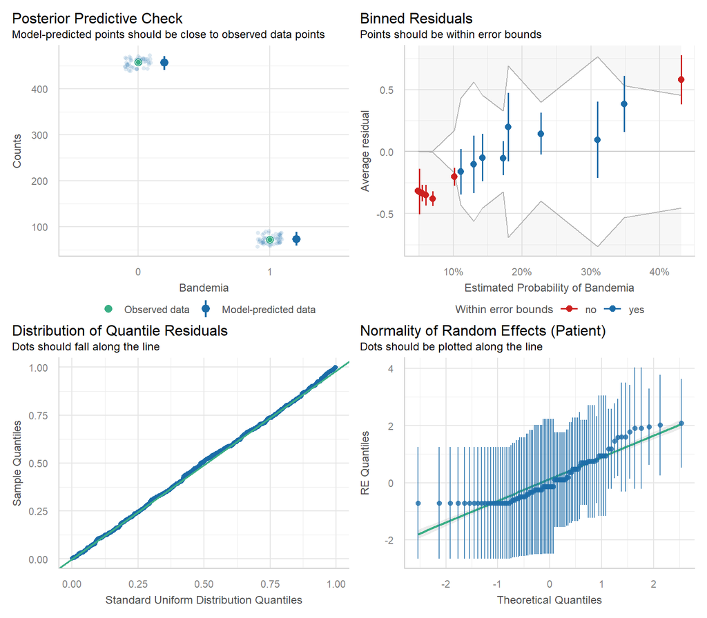

Figure 1: Diagnostic Checks on Model 0

````markdown
```{r}
#| label: fig-check-m0
#| fig-cap: Diagnostic Checks on Model 0
#| fig-height: 7
#| fig-width: 8

check_model(m0, type = "discrete_both", residual_type = "simulated",
            check = c("pp_check", "binned_residuals", "qq", "reqq"),
            base_size = 9)
```
````

Table 3 shows the intraclass correlation (ICC). This is actually the main reason we ran Model 0. Focus on the adjusted ICC. It shows the proportion of variance in the bandemia that is attributable to individual differences between dogs.

````markdown
```{r}
#| label: tbl-m0-icc
#| tbl-cap: Model 0 Intraclass Correlations

# Set random number seed to ensure reproducibility of bootstrap result.
set.seed(26485)

# Bootstrapped 95% CIs via lme4::bootMer()
icc(m0, ci = 0.95, ci_method = NULL, robust = TRUE, iterations = 100) %>%
  as.data.frame() %>%
  t() %>%
  data.frame() %>%
  rename(ICC = X1, LL = X2, UL = X3) %>%
  head(n = 2) %>%
  kable(digits = 2, format.args = list(nsmall = 2)) %>%
  kable_styling() %>%
  add_header_above(header = c(" " = 2, "95% CI" = 2))
```
````

Table 3: Model 0 Intraclass Correlations

|  | ICC | 95% CI LL | 95% CI UL |
| --- | --- | --- | --- |
| ICC_adjusted | 0.33 | 0.18 | 0.54 |
| ICC_unadjusted | 0.33 | 0.18 | 0.54 |

Because Model 0 does not use any substantive predictors, we do not expect its fixed effects to explain any variance. Thus, an marginal R2 of 0 is expected. The conditional R2 includes variance explained by both fixed and random effects, so we expect it to be higher than the marginal R2 (usually by an amount equal to the adjusted ICC).

````markdown
```{r}
#| label: tbl-m0-r2
#| tbl-cap: Model 0 R2 Measures

# Set random number seed to ensure reproducibility of bootstrap result.
set.seed(44512)

# Bootstrapped 95% CIs via lme4::bootMer()
r2(m0, ci = 0.95, ci_method = NULL, robust = TRUE, iterations = 100) %>%
  as.data.frame() %>%
  t() %>%
  data.frame() %>%
  rename(R2 = X1, LL = X2, UL = X3) %>%
  head(n = 2) %>%
  kable(digits = 2, format.args = list(nsmall = 2)) %>%
  kable_styling() %>%
  add_header_above(header = c(" " = 2, "95% CI" = 2))
```
````

Table 4: Model 0 R2 Measures

|  | R2 | 95% CI LL | 95% CI UL |
| --- | --- | --- | --- |
| R2_conditional | 0.33 | 0.13 | 0.49 |
| R2_marginal | 0.00 | 0.00 | 0.00 |

Another thing to examine is the population marginal mean for bandemia prevalence for a typical dog (random effect of 0), which is shown in Table 5.

````markdown
```{r}
#| label: tbl-m0-emm-intercept
#| tbl-cap: Model 0 Population-Average Estimated Marginal Mean (EMM) for Grand Mean

avg_predictions(m0, newdata = Final_Visits, conf_level = 0.95, re.form = NA) %>%
  mutate(p.value = display_num(p.value)) %>%
  select(estimate, std.error, conf.low, conf.high, statistic, p.value, s.value) %>%
  kable(digits = 2, format.args = list(nsmall = 2), align = "r",
        col.names = c("EMM", "SE", "LL", "UL", "z", "p", "s")) %>%
  kable_styling(full_width = FALSE) %>%
  add_header_above(header = c(" " = 2, "95% CI" = 2, "Wald Test" = 2, " "))
```
````

Table 5: Model 0 Population-Average Estimated Marginal Mean (EMM) for Grand Mean

| EMM | SE | 95% CI LL | 95% CI UL | Wald Test z | Wald Test p | s |
| --- | --- | --- | --- | --- | --- | --- |
| 0.09 | 0.02 | 0.05 | 0.14 | 4.43 | 9.63e-06 | 16.66 |

## 4.2 Model 1 (L1 Predictors)

Table 6 shows the parameters for Model 1 and Table 7 shows the corresponding odds-ratios.

````markdown
```{r}
#| label: tbl-m1
#| tbl-cap: Model 1 Parameters
#| results: asis

# Add L1 predictors.
m1 <- glmmTMB(Bandemia ~ DrugC_C + DrugD_C + (1 | Patient),
              data = Final_Visits, family = binomial(link = "logit"),
              ziformula = ~ 0, dispformula = ~ 1, REML = FALSE)

# m1 <- glmmTMB(Bandemia ~ Name + (1 | Patient),
#               data = Final_Visits, family = binomial(link = "logit"),
#               ziformula = ~ 0, dispformula = ~ 1, REML = FALSE)


FN = paste0("Log Likelihood = ", round(logLik(m1), digits = 3),
            ". Deviance = ", round(-2*logLik(m1), digits = 3),
            ". Model df = ", length(m1$fit$par),
            ". Residual df = ", nobs(m1) - length(m1$fit$par),
            ". Drug reference level is Vincristine",
            ". 95% CIs reported.")

modelsummary(list("Model 1" = m1), output = "kableExtra",
             align = "llrrrrr", escape = FALSE,
             col.names = c("Component", "Term", "Est.", "CI.LL", "CI.UL", "z", "p"),
             shape = component + term ~ model + statistic,
             statistic = c("conf.int", "statistic", "p.value"),
             gof_omit = "R2 Marg.|R2 Cond.|ICC",
             notes = FN) %>%
  cat()
```
````

Table 6: Model 1 Parameters

| Component | Term | Model 1 Est. | Model 1 CI.LL | Model 1 CI.UL | Model 1 z | Model 1 p |
| --- | --- | --- | --- | --- | --- | --- |
| conditional | (Intercept) | −2.343 | −2.858 | −1.829 | −8.929 | <0.001 |
|  | DrugC_C | −0.998 | −1.787 | −0.208 | −2.477 | 0.013 |
|  | DrugD_C | 0.147 | −0.545 | 0.839 | 0.416 | 0.677 |
|  | SD (Intercept Patient) | 1.326 | 0.882 | 1.996 |  |  |
|  | Num.Obs. | 530 |  |  |  |  |
|  | AIC | 400.4 |  |  |  |  |
|  | BIC | 417.5 |  |  |  |  |
|  | RMSE | 0.29 |  |  |  |  |

Log Likelihood = -196.208. Deviance = 392.416. Model df = 4. Residual df = 526. Drug reference level is Vincristine. 95% CIs reported.

````markdown
```{r}
#| label: tbl-m1-OR
#| tbl-cap: Model 1 Odds-Ratios

FN = paste0("95% CIs reported.")

modelsummary(list("Model 1" = m1), output = "kableExtra",
             align = "llrrr", escape = FALSE, exponentiate = TRUE,
             col.names = c("Component", "Term", "OR", "OR.LL", "OR.UL"),
             shape = component + term ~ model + statistic,
             statistic = c("conf.int"),
             gof_map = "none",
             notes = list(FN))
```
````

Table 7: Model 1 Odds-Ratios

| Component | Term | Model 1 OR | Model 1 OR.LL | Model 1 OR.UL |
| --- | --- | --- | --- | --- |
| conditional | (Intercept) | 0.096 | 0.057 | 0.161 |
|  | DrugC_C | 0.369 | 0.167 | 0.812 |
|  | DrugD_C | 1.158 | 0.580 | 2.314 |
|  | SD (Intercept Patient) | 1.326 | 0.882 | 1.996 |

95% CIs reported.

Before we do much to interpret the model, we do some quick diagnostic checks. The chunk below should return text describing the result of some checks. The warning it provides is a result of the low prevalence of bandemia in this sample. Because we only added predictors that are dummy codes for drug (a categorical variable), there is no need to check for multicollinearity.

````markdown
```{r}
#| label: diag-m1

diagnose(m1)
#check_collinearity(m1)
```
````

```
Unusually large Z-statistics (|x|>5):

(Intercept)
  -8.928759

Large Z-statistics (estimate/std err) suggest a *possible* failure of
the Wald approximation - often also associated with parameters that are
at or near the edge of their range (e.g. random-effects standard
deviations approaching 0).  (Alternately, they may simply represent
very well-estimated parameters; intercepts of non-centered models may
fall in this category.) While the Wald p-values and standard errors
listed in summary() may be unreliable, profile confidence intervals
(see ?confint.glmmTMB) and likelihood ratio test p-values derived by
comparing models (e.g. ?drop1) are probably still OK.  (Note that the
LRT is conservative when the null value is on the boundary, e.g. a
variance or zero-inflation value of 0 (Self and Liang 1987; Stram and
Lee 1994; Goldman and Whelan 2000); in simple cases these p-values are
approximately twice as large as they should be.)
```

Figure 2 displays some additional graphs used to check model assumptions. While the binned residuals do indicate minor issues with the model especially for situations where the probability of bandemia is very low or very high, the other panels don’t show any cause for major concern.

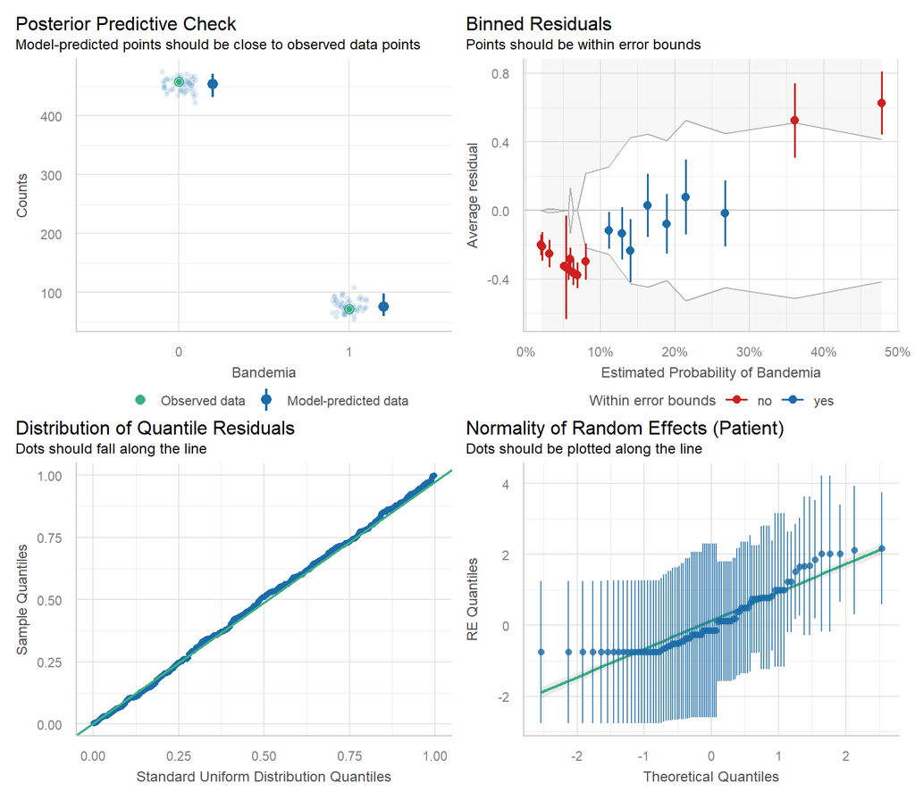

Figure 2: Diagnostic Checks on Model 1

````markdown
```{r}
#| label: fig-check-m1
#| fig-cap: Diagnostic Checks on Model 1
#| fig-height: 7
#| fig-width: 8

check_model(m1, type = "discrete_both", residual_type = "simulated",
            check = c("pp_check", "binned_residuals", "qq", "reqq"),
            base_size = 9)
```
````

Next, we want to see whether Model 1 fit the data better than Model 0. The resulting LRT in Table 8 shows that accounting for which drug was used prior to the visit improves the model.

````markdown
```{r}
#| label: tbl-compare-m0-m1
#| tbl-cap: Likelihood Ratio Test Comparing Models 0 vs 1.

#compare_performance(m1, m2)

test_lrt(m0, m1) %>%
  mutate(Model = case_when(Name == "m0" ~ "No Predictors",
                           Name == "m1" ~ "L1 Predictors")) %>%
  kable(digits = 3, row.names = FALSE) %>%
  kable_styling()
```
````

Table 8: Likelihood Ratio Test Comparing Models 0 vs 1.

| Name | Model | df | df_diff | Chi2 | p |
| --- | --- | --- | --- | --- | --- |
| m0 | No Predictors | 2 | NA | NA | NA |
| m1 | L1 Predictors | 4 | 2 | 8.232 | 0.016 |

Table 9 shows that we still have a similar level of unexplained variability between dogs. That is expected because the visit-level drug predictors were group-mean centered. They can explain variance between visits for the same dog but cannot explain any between-dog variance.

````markdown
```{r}
#| label: tbl-m1-icc
#| tbl-cap: Model 1 Intraclass Correlations

# Set random number seed to ensure reproducibility of bootstrap result.
set.seed(99487)

# Bootstrapped 95% CIs via lme4::bootMer()
icc(m1, ci = 0.95, ci_method = NULL, robust = TRUE, iterations = 100) %>%
  as.data.frame() %>%
  t() %>%
  data.frame() %>%
  rename(ICC = X1, LL = X2, UL = X3) %>%
  head(n = 2) %>%
  kable(digits = 2, format.args = list(nsmall = 2)) %>%
  kable_styling() %>%
  add_header_above(header = c(" " = 2, "95% CI" = 2))
```
````

Table 9: Model 1 Intraclass Correlations

|  | ICC | 95% CI LL | 95% CI UL |
| --- | --- | --- | --- |
| ICC_adjusted | 0.35 | 0.13 | 0.54 |
| ICC_unadjusted | 0.34 | 0.13 | 0.52 |

Table 10 Shows the R2 measures. The marginal R2 tells us how much of the overall variance in bandemia is explained by which drug the dog received prior to the visit’s CBC sample being taken.

````markdown
```{r}
#| label: tbl-m1-r2
#| tbl-cap: Model 1 R2 Measures

# Set random number seed to ensure reproducibility of bootstrap result.
set.seed(32156)

# Bootstrapped 95% CIs via lme4::bootMer()
r2(m1, ci = 0.95, ci_method = NULL, robust = TRUE, iterations = 100) %>%
  as.data.frame() %>%
  t() %>%
  data.frame() %>%
  rename(R2 = X1, LL = X2, UL = X3) %>%
  head(n = 2) %>%
  kable(digits = 2, format.args = list(nsmall = 2)) %>%
  kable_styling() %>%
  add_header_above(header = c(" " = 2, "95% CI" = 2))
```
````

Table 10: Model 1 R2 Measures

|  | R2 | 95% CI LL | 95% CI UL |
| --- | --- | --- | --- |
| R2_conditional | 0.37 | 0.21 | 0.56 |
| R2_marginal | 0.04 | 0.00 | 0.13 |

Table 11 shows that the population marginal mean for bandemia prevalence for a typical dog (random effect of 0) remains similar to that observed in Model 0. That’s what we would expect.

````markdown
```{r}
#| label: tbl-m1-emm-intercept
#| tbl-cap: Model 1 Population-Average Estimated Marginal Mean (EMM) for Grand Mean

avg_predictions(m1, newdata = Final_Visits, conf_level = 0.95, re.form = NA) %>%
  mutate(p.value = display_num(p.value)) %>%
  select(estimate, std.error, conf.low, conf.high, statistic, p.value, s.value) %>%
  kable(digits = 2, format.args = list(nsmall = 2), align = "r",
        col.names = c("EMM", "SE", "LL", "UL", "z", "p", "s")) %>%
  kable_styling(full_width = FALSE) %>%
  add_header_above(header = c(" " = 2, "95% CI" = 2, "Wald Test" = 2, " "))
```
````

Table 11: Model 1 Population-Average Estimated Marginal Mean (EMM) for Grand Mean

| EMM | SE | 95% CI LL | 95% CI UL | Wald Test z | Wald Test p | s |
| --- | --- | --- | --- | --- | --- | --- |
| 0.09 | 0.02 | 0.05 | 0.14 | 4.35 | 1.35e-05 | 16.18 |

Table 12 shows the population average estimated marginal means for bandemia prevalence associated with each drug. The estimates assume a typical dog (i.e., one with a random intercept of 0).

````markdown
```{r}
#| label: tbl-m1-emm-name
#| tbl-cap: Model 1 Population-Average Estimated Marginal Mean (EMM) by Drug
#|          Main Effect at Level 1

avg_predictions(m1, newdata = Final_Visits, conf_level = 0.95, re.form = NA,
                by = c("Name"))  %>%
  mutate(p.value = display_num(p.value)) %>%
  select(Name, estimate, std.error, conf.low, conf.high, statistic, p.value,
         s.value) %>%
  kable(digits = 2, format.args = list(nsmall = 2), align = "r",
        col.names = c("Name","EMM", "SE", "LL", "UL", "z", "p", "s")) %>%
  kable_styling(full_width = FALSE) %>%
  add_header_above(header = c(" " = 3, "95% CI" = 2, "Wald Test" = 2, " "))
```
````

Table 12: Model 1 Population-Average Estimated Marginal Mean (EMM) by Drug Main Effect at Level 1

| Name | EMM | SE | 95% CI LL | 95% CI UL | Wald Test z | Wald Test p | s |
| --- | --- | --- | --- | --- | --- | --- | --- |
| Vincristine | 0.11 | 0.03 | 0.06 | 0.16 | 4.05 | 5.14e-05 | 14.25 |
| Cyclophosphamide | 0.04 | 0.02 | 0.01 | 0.08 | 2.48 | 0.013 | 6.25 |
| Doxorubicin | 0.12 | 0.04 | 0.05 | 0.19 | 3.20 | 0.001 | 9.51 |

## 4.3 Model 2 (L1 & L2 Predictors)

Table 13 shows the parameters for Model 2, which includes all the variables we intend to test and Table 14 shows the corresponding odds-ratios.

````markdown
```{r}
#| label: tbl-m2
#| tbl-cap: Model 2 Parameters
#| results: asis

# Add L2 predictors
m2 <- glmmTMB(Bandemia ~ DrugC_C + DrugD_C + M_DrugC + M_DrugD + BSA_m2_C +
              (1 | Patient),
              data = Final_Visits, family = binomial(link = "logit"),
              ziformula = ~ 0, dispformula = ~ 1, REML = FALSE)

FN = paste0("Log Likelihood = ", round(logLik(m2), digits = 3),
            ". Deviance = ", round(-2*logLik(m2), digits = 3),
            ". Model df = ", length(m2$fit$par),
            ". Residual df = ", nobs(m2) - length(m2$fit$par),
            ". Drug reference level is Vincristine",
            ". 95% CIs reported.")

modelsummary(list("Model 2" = m2), output = "kableExtra",
             align = "llrrrrr", escape = FALSE,
             col.names = c("Component", "Term", "Est.", "CI.LL", "CI.UL", "z", "p"),
             shape = component + term ~ model + statistic,
             statistic = c("conf.int", "statistic", "p.value"),
             gof_omit = "R2 Marg.|R2 Cond.|ICC",
             notes = list(FN, paste("95% CIs reported.")),
             footnote_as_chunk = TRUE) %>%
  cat()
```
````

Table 13: Model 2 Parameters

| Component | Term | Model 2 Est. | Model 2 CI.LL | Model 2 CI.UL | Model 2 z | Model 2 p |
| --- | --- | --- | --- | --- | --- | --- |
| conditional | (Intercept) | −2.489 | −4.281 | −0.696 | −2.721 | 0.007 |
|  | DrugC_C | −0.984 | −1.766 | −0.202 | −2.465 | 0.014 |
|  | DrugD_C | 0.164 | −0.540 | 0.869 | 0.457 | 0.647 |
|  | M_DrugC | 2.113 | −2.231 | 6.456 | 0.953 | 0.340 |
|  | M_DrugD | −2.289 | −6.875 | 2.296 | −0.978 | 0.328 |
|  | BSA_m2_C | −1.344 | −2.579 | −0.109 | −2.133 | 0.033 |
|  | SD (Intercept Patient) | 1.220 | 0.798 | 1.865 |  |  |
|  | Num.Obs. | 530 |  |  |  |  |
|  | AIC | 397.5 |  |  |  |  |
|  | BIC | 427.4 |  |  |  |  |
|  | RMSE | 0.29 |  |  |  |  |

Log Likelihood = -191.753. Deviance = 383.505. Model df = 7. Residual df = 523. Drug reference level is Vincristine. 95% CIs reported.

````markdown
```{r}
#| label: tbl-m2-OR
#| tbl-cap: Model 2 Odds-Ratios

FN = paste0("95% CIs reported.")

modelsummary(list("Model 2" = m2), output = "kableExtra",
             align = "llrrr", escape = FALSE, exponentiate = TRUE,
             col.names = c("Component", "Term", "OR", "OR.LL", "OR.UL"),
             shape = component + term ~ model + statistic,
             statistic = c("conf.int"),
             gof_map = "none",
             notes = FN)
```
````

Table 14: Model 2 Odds-Ratios

| Component | Term | Model 2 OR | Model 2 OR.LL | Model 2 OR.UL |
| --- | --- | --- | --- | --- |
| conditional | (Intercept) | 0.083 | 0.014 | 0.499 |
|  | DrugC_C | 0.374 | 0.171 | 0.817 |
|  | DrugD_C | 1.179 | 0.583 | 2.385 |
|  | M_DrugC | 8.271 | 0.107 | 636.722 |
|  | M_DrugD | 0.101 | 0.001 | 9.938 |
|  | BSA_m2_C | 0.261 | 0.076 | 0.897 |
|  | SD (Intercept Patient) | 1.220 | 0.798 | 1.865 |

95% CIs reported.

````markdown
```{r}
#| label: diag-m2

diagnose(m2)
check_collinearity(m2)
```
````

```
model looks OK!
# Check for Multicollinearity

Low Correlation

     Term  VIF     VIF 95% CI adj. VIF Tolerance Tolerance 95% CI
  DrugC_C 1.05 [1.01,   1.32]     1.02      0.95     [0.76, 0.99]
  DrugD_C 1.05 [1.01,   1.32]     1.02      0.95     [0.76, 0.99]
  M_DrugC 1.28 [1.18,   1.45]     1.13      0.78     [0.69, 0.85]
  M_DrugD 1.27 [1.17,   1.44]     1.13      0.78     [0.69, 0.85]
 BSA_m2_C 1.01 [1.00, 118.94]     1.00      0.99     [0.01, 1.00]
```

Figure 3 displays some additional graphs used to check model assumptions. While the binned residuals do indicate minor issues with the model especially for situations where the probability of bandemia is very low or very high, the other panels don’t show any cause for major concern.

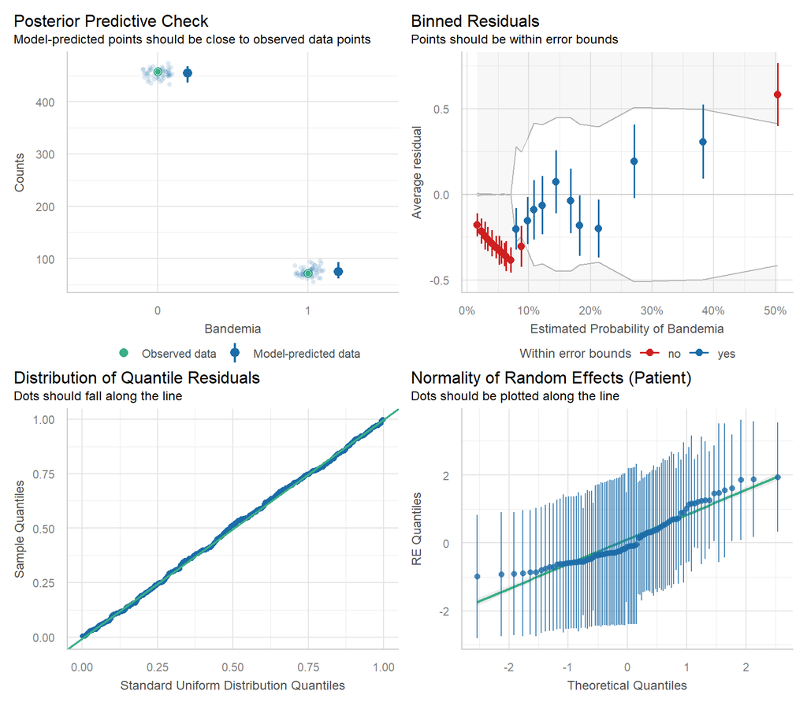

Figure 3: Diagnostic Checks on Model 2

````markdown
```{r}
#| label: fig-check-m2
#| fig-cap: Diagnostic Checks on Model 2
#| fig-height: 7
#| fig-width: 8

check_model(m2, type = "discrete_both", residual_type = "simulated",
            check = c("pp_check", "binned_residuals", "qq", "reqq"),
            base_size = 9)
```
````

Table 15 shows comparisons between Models 0, 1, and 2. It is clear that Model 1 is an improvement over Model 0, and that Model2 is an improvement over model 1.

````markdown
```{r}
#| label: tbl-compare-m0-m1-m2
#| tbl-cap: Likelihood Ratio Tests Comparing Models 0, 1, and 2.

bind_rows(test_lrt(m0, m2),
          test_lrt(m1, m2)) %>%
  mutate(Model = case_when(Name == "m0" ~ "No Predictors",
                           Name == "m1" ~ "L1 Predictors",
                           Name == "m2" ~ "L1 & L2 Predictors (BSA, Drug)")) %>%
  kable(digits = 3, row.names = FALSE) %>%
  kable_styling() %>%
  group_rows(., group_label = "Model 0 vs Model 2", start_row = 1, end_row = 2) %>%
  group_rows(., group_label = "Model 1 vs Model 2", start_row = 3, end_row = 4)
```
````

Table 15: Likelihood Ratio Tests Comparing Models 0, 1, and 2.

| Name | Model | df | df_diff | Chi2 | p |
| --- | --- | --- | --- | --- | --- |
| **Model 0 vs Model 2** |  |  |  |  |  |
| m0 | No Predictors | 2 | NA | NA | NA |
| m2 | L1 & L2 Predictors (BSA, Drug) | 7 | 5 | 17.143 | 0.004 |
| **Model 1 vs Model 2** |  |  |  |  |  |
| m1 | L1 Predictors | 4 | NA | NA | NA |
| m2 | L1 & L2 Predictors (BSA, Drug) | 7 | 3 | 8.911 | 0.030 |

**Important**

We should interpret Model 2 instead of Model 1.

Table 16 shows that we still have had a small decrease in unexplained variability between dogs compared wo what we saw in Model 1. This is expected given that BSA appears to be a meaningful predictor of bandemia in Table 13.

````markdown
```{r}
#| label: tbl-m2-icc
#| tbl-cap: Model 2 Intraclass Correlations

# Set random number seed to ensure reproducibility of bootstrap result.
set.seed(74156)

# Bootstrapped 95% CIs via lme4::bootMer()
icc(m2, ci = 0.95, ci_method = NULL, robust = TRUE, iterations = 100) %>%
  as.data.frame() %>%
  t() %>%
  data.frame() %>%
  rename(ICC = X1, LL = X2, UL = X3) %>%
  head(n = 2) %>%
  kable(digits = 2, format.args = list(nsmall = 2)) %>%
  kable_styling() %>%
  add_header_above(header = c(" " = 2, "95% CI" = 2))
```
````

Table 16: Model 2 Intraclass Correlations

|  | ICC | 95% CI LL | 95% CI UL |
| --- | --- | --- | --- |
| ICC_adjusted | 0.31 | 0.05 | 0.50 |
| ICC_unadjusted | 0.28 | 0.04 | 0.45 |

Table 17 shows the marginal R2 for Model 2. It is notably larger than it was in Model 1. This is also consistent with the presence of BAS as a meaningful L2 predictor.

````markdown
```{r}
#| label: tbl-m2-r2
#| tbl-cap: Model 2 R2 Measures

# Set random number seed to ensure reproducibility of bootstrap result.
set.seed(84361)

# Bootstrapped 95% CIs via lme4::bootMer()
r2(m2, ci = 0.95, ci_method = NULL, robust = TRUE, iterations = 100) %>%
  as.data.frame() %>%
  t() %>%
  data.frame() %>%
  rename(R2 = X1, LL = X2, UL = X3) %>%
  head(n = 2) %>%
  kable(digits = 2, format.args = list(nsmall = 2)) %>%
  kable_styling() %>%
  add_header_above(header = c(" " = 2, "95% CI" = 2))
```
````

Table 17: Model 2 R2 Measures

|  | R2 | 95% CI LL | 95% CI UL |
| --- | --- | --- | --- |
| R2_conditional | 0.38 | 0.19 | 0.57 |
| R2_marginal | 0.10 | 0.04 | 0.26 |

Table 18 shows that the population marginal mean for bandemia prevalence for a typical dog (random effect of 0) remains similar to that observed in Model 0. That’s what we would expect.

````markdown
```{r}
#| label: tbl-m2-emm-intercept
#| tbl-cap: Model 2 Population-Average Estimated Marginal Mean (EMM) for Grand Mean

avg_predictions(m2, newdata = Final_Visits, conf_level = 0.95, re.form = NA) %>%
  mutate(p.value = display_num(p.value)) %>%
  select(estimate, std.error, conf.low, conf.high, statistic, p.value, s.value) %>%
  kable(digits = 2, format.args = list(nsmall = 2), align = "r",
        col.names = c("EMM", "SE", "LL", "UL", "z", "p", "s")) %>%
  kable_styling(full_width = FALSE) %>%
  add_header_above(header = c(" " = 2, "95% CI" = 2, "Wald Test" = 2, " "))
```
````

Table 18: Model 2 Population-Average Estimated Marginal Mean (EMM) for Grand Mean

| EMM | SE | 95% CI LL | 95% CI UL | Wald Test z | Wald Test p | s |
| --- | --- | --- | --- | --- | --- | --- |
| 0.10 | 0.02 | 0.06 | 0.14 | 4.78 | 1.74e-06 | 19.13 |

````markdown
```{r}
#| label: tbl-m2-emm-name
#| tbl-cap: Model 2 Population-Average Estimated Marginal Mean (EMM) for
#|          Bandemia by Drug (Main Effect at Level 1)

avg_predictions(m2, newdata = Final_Visits, conf_level = 0.95, re.form = NA,
                by = c("Name"))  %>%
  mutate(p.value = display_num(p.value)) %>%
  select(Name, estimate, std.error, conf.low, conf.high, statistic, p.value,
         s.value) %>%
  kable(digits = 2, format.args = list(nsmall = 2), align = "r",
        col.names = c("Name","EMM", "SE", "LL", "UL", "z", "p", "s")) %>%
  kable_styling(full_width = FALSE) %>%
  add_header_above(header = c(" " = 3, "95% CI" = 2, "Wald Test" = 2, " "))
```
````

Table 19: Model 2 Population-Average Estimated Marginal Mean (EMM) for Bandemia by Drug (Main Effect at Level 1)

| Name | EMM | SE | 95% CI LL | 95% CI UL | Wald Test z | Wald Test p | s |
| --- | --- | --- | --- | --- | --- | --- | --- |
| Vincristine | 0.12 | 0.03 | 0.06 | 0.17 | 4.47 | 7.97e-06 | 16.94 |
| Cyclophosphamide | 0.06 | 0.02 | 0.02 | 0.10 | 2.69 | 0.007 | 7.14 |
| Doxorubicin | 0.11 | 0.04 | 0.04 | 0.19 | 3.16 | 0.002 | 9.32 |

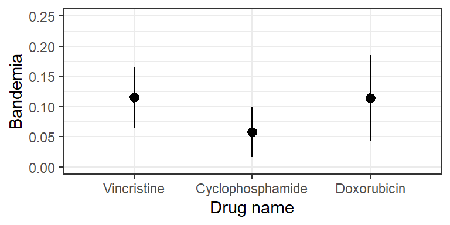

Figure 4

````markdown
```{r}
#| label: fig-m2-emm-name
#| tbl-cap: Model 2 Population-Average Estimated Marginal Means (EMMs) for
#|          Bandemia by Drug (Main Effect at Level 1)
#| fig-width: 4
#| fig-height: 2

Fig3 <- plot_predictions(m2, newdata = Final_Visits, conf_level = 0.95, re.form = NA,
                by = c("Name"), vcov = TRUE) +
  theme_bw() +
  coord_cartesian(ylim = c(0, 0.25)) +
  labs(x = "Drug name", y = "Bandemia")

Fig3

# Export figure for use in journal submission
ggsave(filename = here(paste0("scripts/output/Figure_3.png")), plot = Fig3,
       device = "png", width = 4, height = 2, units = "in", dpi = 600)
```
````

**Important**

Figure 4 will be Figure 3 in the manuscript we are preparing (Eliason et al., 2026).

The simplest way to compare the bandemia rates is by examining the risk difference between each pair of drugs, as shown in Table 20. The risk difference (RD) is simply subtracting one rate from the other.

````markdown
```{r}
#| label: tbl-m2-RD-name
#| tbl-cap: Model 2 Population-Average Bandemia Risk Differences Between
#|          Different Drugs

# Omit warning message about specifying hypothesis tests using positional
# indices like b1, b2, etc. I've verified that this is correct.
options(marginaleffects_safe = FALSE)

avg_predictions(m2, newdata = Final_Visits, conf_level = 0.95, re.form = NA,
                hypothesis = c("Vincristine - Cyclophosphamide" =  "b1 - b2 = 0",
                               "Vincristine - Doxorubicin" =  "b1 - b3 = 0",
                               "Doxorubicin - Cyclophosphamide" =  "b3 - b2 = 0"),
                by = "Name")  %>%
  mutate(p.value = display_num(p.value)) %>%
  select(hypothesis, estimate, std.error, conf.low, conf.high, statistic, p.value,
         s.value) %>%
  kable(digits = 2, format.args = list(nsmall = 2), align = "r",
        col.names = c("Hypothesis","RD", "SE", "LL", "UL", "z", "p", "s")) %>%
  kable_styling(full_width = FALSE) %>%
  add_header_above(header = c(" " = 3, "95% CI" = 2, "Wald Test" = 2, " "))
```
````

Table 20: Model 2 Population-Average Bandemia Risk Differences Between Different Drugs

| Hypothesis | RD | SE | 95% CI LL | 95% CI UL | Wald Test z | Wald Test p | s |
| --- | --- | --- | --- | --- | --- | --- | --- |
| Vincristine - Cyclophosphamide | 0.06 | 0.03 | 0.01 | 0.11 | 2.18 | 0.029 | 5.10 |
| Vincristine - Doxorubicin | 0.00 | 0.04 | -0.07 | 0.07 | 0.03 | 0.980 | 0.03 |
| Doxorubicin - Cyclophosphamide | 0.06 | 0.04 | -0.02 | 0.13 | 1.54 | 0.123 | 3.03 |

**Caution**

In Table 20 the p-value for the difference in bandemia rates between doxorubicin and cyclophoshamide is not significant but the lower CI bound is just barely below 0. We can’t conclude there is a difference between those bandemia rates even though the point estimate for the risk difference matches that of the risk difference between vincristine and cyclophoshamide. That’s because we have less data about doxorubicin than vincristine, so there is more uncertainty about its marginal mean and differences between it and other those of drugs. You can see that in the wider confidence interval for doxorubicin in Figure 4.

In this study BSA is a patient-level variable rather than visit-level variable because only BSA at the start of CHOP was recorded and used in Model 2. Figure 5 shows the marginal effect of BSA on bandemia prevalence. The prevalence decreases considerably as BSA increases. The predicted value for the smallest dog in the sample is around 19%, while for dogs of average size (centered BSA values of 0) the rate is around 8%, and for the largest dog it is around 2.5%.

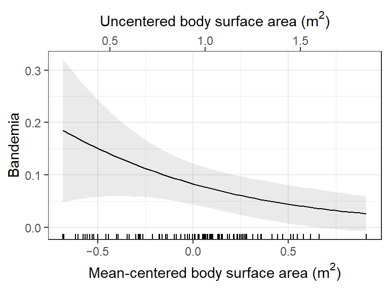

Figure 5

````markdown
```{r}
#| label: fig-m2-BSA
#| tbl-cap: Model 2 Population-Average Predicted Bandemia by Body Surface Area
#|          Main Effect at Level 2
#| fig-width: 4
#| fig-height: 3

Fig2 <- plot_predictions(m2, newdata = Final_Visits, conf_level = 0.95,
                         re.form = NA, condition = c("BSA_m2_C"), vcov = TRUE) +
  scale_x_continuous(name = expression("Mean-centered body surface area (" *  m^2 * ")"),
                     breaks = c(-0.5, 0, 0.5),
                     # Journal wants minus sign ("−") instead of hyphen ("-")
                     labels = c("−0.5", "0.0", "0.5"),
                     sec.axis = sec_axis(~ . + mean(Final_Patients$Surface_Area_m2),
                                         name = expression("Uncentered body surface area (" * m^2 * ")"))) +
  geom_rug(aes(x = Surface_Area_m2 - mean(Surface_Area_m2)),
               data = Final_Patients) +
  theme_bw() +
  labs(y = "Bandemia")

Fig2

# Export figure for use in journal submission
ggsave(filename = here(paste0("scripts/output/Figure_2.png")), plot = Fig2,
       device = "png", width = 4, height = 3, units = "in", dpi = 600)
```
````

**Important**

Figure 5 will be Figure 2 in the manuscript we are preparing (Eliason et al., 2026).

Figure 6 and Figure 7 respectively show the marginal effects of mean exposure to cyclophosphamide and doxorubicin. Here, mean exposure refers to the proportion of visits at which the indicated drug was administered. These plots are consistent with Table 13, which shows that neither of those variables had noteworthy effects on bandemia prevalence.

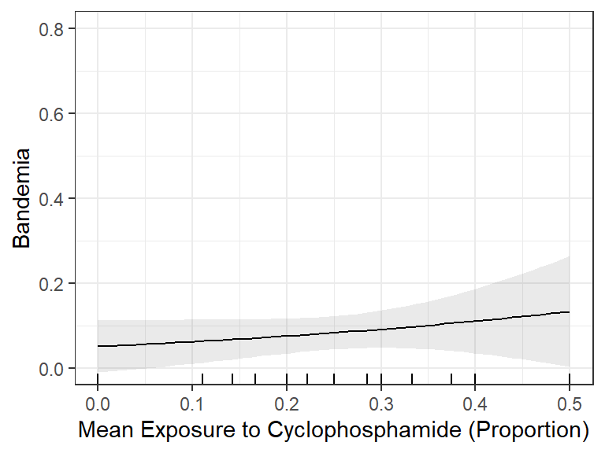

Figure 6

````markdown
```{r}
#| label: fig-m2-M-DrugC
#| tbl-cap: Model 2 Population-Average Predicted Bandemia by Mean Exposure to
#|          Clyclophosphamide Main Effect at Level 2
#| fig-width: 4
#| fig-height: 3

plot_predictions(m2, newdata = Final_Visits, conf_level = 0.95, re.form = NA,
                condition = c("M_DrugC"), vcov = TRUE) +
  geom_rug(aes(x = M_DrugC), data = Final_Patients) +
  theme_bw() +
  coord_cartesian(ylim = c(0.00, 0.80)) +
  labs(x = "Mean Exposure to Cyclophosphamide (Proportion)",
       y = "Bandemia")
```
````

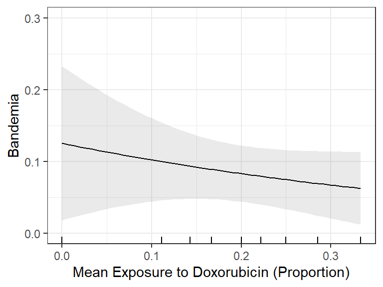

Figure 7

````markdown
```{r}
#| label: fig-m2-M-DrugD
#| tbl-cap: Model 2 Population-Average Predicted Bandemia by Mean Exposure to
#|          Doxorubicin Main Effect at Level 2
#| fig-width: 4
#| fig-height: 3

plot_predictions(m2, newdata = Final_Visits, conf_level = 0.95, re.form = NA,
                condition = c("M_DrugD"), vcov = TRUE) +
  geom_rug(aes(x = M_DrugD), data = Final_Patients) +
  theme_bw() +
  coord_cartesian(ylim = c(0.00, 0.30)) +
  labs(x = "Mean Exposure to Doxorubicin (Proportion)",
       y = "Bandemia")
```
````

## 4.4 Model 3 (L1 & More L2 Predictors)

Table 21 shows the parameters for Model 3, which includes all the variables we intend to test and Table 22 shows the corresponding odds-ratios.

````markdown
```{r}
#| label: tbl-m3
#| tbl-cap: Model 3 Parameters
#| results: asis

# Add L2 predictors
m3 <- glmmTMB(Bandemia ~ DrugC_C + DrugD_C + M_DrugC + M_DrugD + Age_Yrs_C +
                BSA_m2_C + Sex + (1 | Patient),
              data = Final_Visits, family = binomial(link = "logit"),
              ziformula = ~ 0, dispformula = ~ 1, REML = FALSE)

FN = paste0("Log Likelihood = ", round(logLik(m2), digits = 3),
            ". Deviance = ", round(-2*logLik(m2), digits = 3),
            ". Model df = ", length(m2$fit$par),
            ". Residual df = ", nobs(m2) - length(m2$fit$par),
            ". Drug reference level is Vincristine",
            ". 95% CIs reported.")

modelsummary(list("Model 3" = m3), output = "kableExtra",
             align = "llrrrrr", escape = FALSE,
             col.names = c("Component", "Term", "Est.", "CI.LL", "CI.UL", "z", "p"),
             shape = component + term ~ model + statistic,
             statistic = c("conf.int", "statistic", "p.value"),
             gof_omit = "R2 Marg.|R2 Cond.|ICC",
             notes = list(FN, paste("95% CIs reported.")),
             footnote_as_chunk = TRUE) %>%
  cat()
```
````

Table 21: Model 3 Parameters

| Component | Term | Model 3 Est. | Model 3 CI.LL | Model 3 CI.UL | Model 3 z | Model 3 p |
| --- | --- | --- | --- | --- | --- | --- |
| conditional | (Intercept) | −2.540 | −4.443 | −0.637 | −2.616 | 0.009 |
|  | DrugC_C | −0.984 | −1.767 | −0.202 | −2.465 | 0.014 |
|  | DrugD_C | 0.164 | −0.540 | 0.869 | 0.457 | 0.648 |
|  | M_DrugC | 2.127 | −2.231 | 6.484 | 0.957 | 0.339 |
|  | M_DrugD | −2.455 | −7.047 | 2.137 | −1.048 | 0.295 |
|  | Age_Yrs_C | 0.046 | −0.114 | 0.205 | 0.561 | 0.575 |
|  | BSA_m2_C | −1.268 | −2.625 | 0.090 | −1.830 | 0.067 |
|  | SexM | 0.136 | −0.730 | 1.001 | 0.307 | 0.759 |
|  | SD (Intercept Patient) | 1.209 | 0.790 | 1.852 |  |  |
|  | Num.Obs. | 530 |  |  |  |  |
|  | AIC | 401.1 |  |  |  |  |
|  | BIC | 439.6 |  |  |  |  |
|  | RMSE | 0.29 |  |  |  |  |

````markdown
```{r}
#| label: tbl-m3-OR
#| tbl-cap: Model 3 Odds-Ratios

FN = paste0("95% CIs reported.")

modelsummary(list("Model 3" = m3), output = "kableExtra",
             align = "llrrr", escape = FALSE, exponentiate = TRUE,
             col.names = c("Component", "Term", "OR", "OR.LL", "OR.UL"),
             shape = component + term ~ model + statistic,
             statistic = c("conf.int"),
             gof_map = "none",
             notes = FN)
```
````

Table 22: Model 3 Odds-Ratios

| Component | Term | Model 3 OR | Model 3 OR.LL | Model 3 OR.UL |
| --- | --- | --- | --- | --- |
| conditional | (Intercept) | 0.079 | 0.012 | 0.529 |
|  | DrugC_C | 0.374 | 0.171 | 0.817 |
|  | DrugD_C | 1.179 | 0.583 | 2.384 |
|  | M_DrugC | 8.386 | 0.107 | 654.338 |
|  | M_DrugD | 0.086 | 0.001 | 8.472 |
|  | Age_Yrs_C | 1.047 | 0.893 | 1.227 |
|  | BSA_m2_C | 0.282 | 0.072 | 1.094 |
|  | SexM | 1.145 | 0.482 | 2.721 |
|  | SD (Intercept Patient) | 1.209 | 0.790 | 1.852 |

95% CIs reported.

````markdown
```{r}
#| label: diag-m3

diagnose(m3)
check_collinearity(m3)
```
````

```
model looks OK!
# Check for Multicollinearity

Low Correlation

      Term  VIF   VIF 95% CI adj. VIF Tolerance Tolerance 95% CI
   DrugC_C 1.05 [1.01, 1.31]     1.02      0.95     [0.76, 0.99]
   DrugD_C 1.05 [1.01, 1.32]     1.02      0.95     [0.76, 0.99]
   M_DrugC 1.30 [1.19, 1.46]     1.14      0.77     [0.68, 0.84]
   M_DrugD 1.29 [1.18, 1.46]     1.14      0.77     [0.69, 0.84]
 Age_Yrs_C 1.15 [1.07, 1.31]     1.07      0.87     [0.76, 0.93]
  BSA_m2_C 1.23 [1.13, 1.39]     1.11      0.81     [0.72, 0.88]
       Sex 1.11 [1.04, 1.28]     1.05      0.90     [0.78, 0.96]
```

Figure 8 displays some additional graphs used to check model assumptions. While the binned residuals do indicate minor issues with the model especially for situations where the probability of bandemia is very low or very high, the other panels don’t show any cause for major concern.

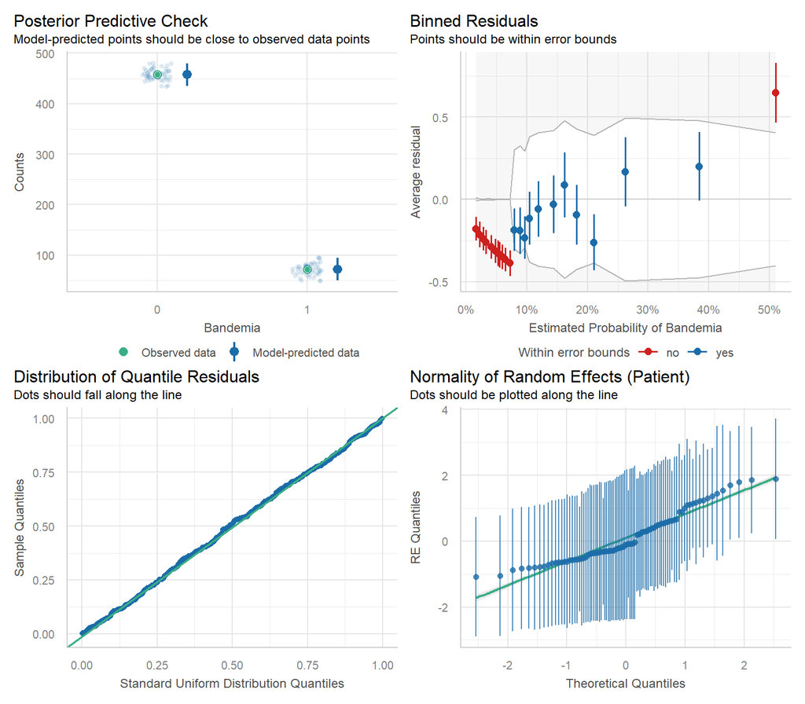

Figure 8: Diagnostic Checks on Model 3

````markdown
```{r}
#| label: fig-check-m3
#| fig-cap: Diagnostic Checks on Model 3
#| fig-height: 7
#| fig-width: 8

check_model(m3, type = "discrete_both", residual_type = "simulated",
            check = c("pp_check", "binned_residuals", "qq", "reqq"),
            base_size = 9)
```
````

Table 23 shows comparisons between Models 1, 2, and 3. It is clear that Model 2 is an improvement over Model 1, and that Model 3 is not an improvement over Model 1 or Model 2.

````markdown
```{r}
#| label: tbl-compare-m1-m2-m3
#| tbl-cap: Likelihood Ratio Tests Comparing Models 1, 2, and 3.

bind_rows(test_lrt(m1, m2),
          test_lrt(m1, m3),
          test_lrt(m2, m3)) %>%
  mutate(Model = case_when(Name == "m0" ~ "No Predictors",
                           Name == "m1" ~ "L1 Predictors",
                           Name == "m2" ~ "L1 & L2 Predictors (BSA, Drug)",
                           Name == "m3" ~ "L1 & L2 Predictors (BSA, Drug, Age, Sex)"),
         ) %>%
  kable(digits = 3, row.names = FALSE) %>%
  kable_styling() %>%
  group_rows(., group_label = "Model 1 vs Model 2", start_row = 1, end_row = 2) %>%
  group_rows(., group_label = "Model 1 vs Model 3", start_row = 3, end_row = 4) %>%
  group_rows(., group_label = "Model 2 vs Model 3", start_row = 5, end_row = 6)
```
````

Table 23: Likelihood Ratio Tests Comparing Models 1, 2, and 3.

| Name | Model | df | df_diff | Chi2 | p |
| --- | --- | --- | --- | --- | --- |
| **Model 1 vs Model 2** |  |  |  |  |  |
| m1 | L1 Predictors | 4 | NA | NA | NA |
| m2 | L1 & L2 Predictors (BSA, Drug) | 7 | 3 | 8.911 | 0.030 |
| **Model 1 vs Model 3** |  |  |  |  |  |
| m1 | L1 Predictors | 4 | NA | NA | NA |
| m3 | L1 & L2 Predictors (BSA, Drug, Age, Sex) | 9 | 5 | 9.320 | 0.097 |
| **Model 2 vs Model 3** |  |  |  |  |  |
| m2 | L1 & L2 Predictors (BSA, Drug) | 7 | NA | NA | NA |
| m3 | L1 & L2 Predictors (BSA, Drug, Age, Sex) | 9 | 2 | 0.409 | 0.815 |

**Important**

Table 23 suggests that we should interpret Model 2 instead of Model 3. We can mention in the paper that adding age and sex effects did not improve the model, but that can be a brief aside (just one sentence).

Table 21 shows that in Model 3 neither age nor sex had clear effect on bandemia. Comparing Table 14 and Table 22 shows that adding age and sex to the model makes the confidence interval for the odds-ratio of the BSA effect a bit wider. It widens enough to span a value of 1. The bulk of the CI still suggests the effect is probably negative, but we cannot exclude the possibility of either no effect or a very small positive effect. However, on balance, there remains a fair degree of overlap between the BSA CIs for Model 2 and Model 3 and we have reason to rely more on Model 2.

# 5 References

Arel-Bundock, V., Greifer, N., & Heiss, A. (2024). How to interpret statistical models using marginaleffects for R and Python. *Journal of Statistical Software*, *111*(9), 1–32. https://doi.org/10.18637/jss.v111.i09

Brooks, M. E., Kristensen, K., Benthem, K. J. van, Magnusson, A., Berg, C. W., Nielsen, A., Skaug, H. J., Mächler, M., & Bolker, B. M. (2017). glmmTMB balances speed and flexibility among packages for zero-inflated generalized linear mixed modeling. *The R Journal*, *9*(2), 378–400. https://doi.org/10.32614/RJ-2017-066

Fox, J. (2016). *Applied regression analysis and generalized linear models* (3rd ed.). Sage Publications, Inc.

Fox, J., & Weisberg, S. (2019). *An R companion to applied regression* (3rd ed.). Sage. https://www.john-fox.ca/Companion/

Hartig, F. (2024). *DHARMa: Residual Diagnostics for Hierarchical (Multi-Level / Mixed) Regression Models* (Version 0.4.7) [Computer Program, R Package]. The Comprehensive R Archive Network. https://CRAN.R-project.org/package=DHARMa

Lüdecke, D., Ben-Shachar, M. S., Patil, I., Waggoner, P., & Makowski, D. (2021). performance: An R package for assessment, comparison and testing of statistical models. *Journal of Open Source Software*, *6*(60), 3139. https://doi.org/10.21105/joss.03139

McGillycuddy, M., Popovic, G., Bolker, B. M., & Warton, D. I. (2025). Parsimoniously fitting large multivariate random effects in glmmTMB. *Journal of Statistical Software*, *112*(1), 1–19. https://doi.org/10.18637/jss.v112.i01

Nakagawa, S., Johnson, P. C. D., & Schielzeth, H. (2017). The coefficient of determination R2 and intra-class correlation coefficient from generalized linear mixed-effects models revisited and expanded [Journal Article]. *Journal of The Royal Society Interface*, *14*(134), 20170213. https://doi.org/10.1098/rsif.2017.0213

Pierce, S. J. (2026). *CHOPStudy: Research compendium for the CHOP study* (Version 1.0.3) [Reproducible Research Materials, Computer Program, R package, Public Repository]. GitHub. https://github.com/sjpierce/CHOPStudy. Zenodo. https://doi.org/10.5281/zenodo.18381003

Rights, J. D., Preacher, K. J., & Cole, D. A. (2020). The danger of conflating level‐specific effects of control variables when primary interest lies in level‐2 effects. *British Journal of Mathematical and Statistical Psychology*, *73*(S1), 194–211. https://doi.org/10.1111/bmsp.12194

Rights, J. D., & Sterba, S. K. (2023). On the common but problematic specification of conflated random slopes in multilevel models. *Multivariate Behavioral Research*, *58*(6), 1106–1133. https://doi.org/10.1080/00273171.2023.2174490

Schielzeth, H. (2010). Simple means to improve the interpretability of regression coefficients. *Methods in Ecology and Evolution*, *1*(2), 103–113. https://doi.org/10.1111/j.2041-210X.2010.00012.x

Yaremych, H. E., Preacher, K. J., & Hedeker, D. (2023). Centering categorical predictors in multilevel models: Best practices and interpretation. *Psychological Methods*, *28*(3), 613–630. https://doi.org/10.1037/met0000434

# 6 Software Information

This section documents information that is important for reproducibility. Most users will not need to read it. It is primarily here for use by the statistician on the team.

We used [R](https://www.r-project.org/) as our main computing environment and [Quarto](https://quarto.org/) scripts to enhance reproducibility. We used RStudio as the editor to interface with R and Quarto.

- Software chain: **qmd file > RStudio > Quarto > R > knitr > md file > Pandoc > HTML file**.
- Source file: **GLMM_Analysis.qmd**
- Output file: **GLMM_Analysis_2026-01-29.html**
- [Quarto 1.8.27](https://quarto.org/) runs `*.qmd` files through [R](https://www.r-project.org/) and [knitr](https://yihui.org/knitr/) to produce `*.md` markdown files.
- [Pandoc 3.6.3](https://pandoc.org) converts markdown files (`*.md`) to other formats, including LaTeX (`*.tex`) and HTML (`*.html`) among others.

## 6.1 Versions

## 6.2 Git Details

The current Git commit details and status are:

```r
git_report()
```

```
Local:    main P:/Consulting/Cases_1200-1399/C1358/CHOPStudy
Remote:   main @ origin (https://github.com/sjpierce/CHOPStudy.git)
Head:     [e5b6ca2] 2026-01-29: Update news.
```

```
Untracked files:
    Untracked:  scripts/GLMM_Analysis.rmarkdown
    Untracked:  scripts/GLMM_Analysis_files/
    Untracked:  scripts/Render_Scripts.rmarkdown
```